# Part II - FordGo Bike Investigation

## Dataset Overview

> The FordGo Bike dataset uses data collected through the month of February,2019. There were approximately 183,412 bike rides collected. This dataset can be gotten in CSV format [here](https://video.udacity-data.com/topher/2020/October/5f91cf38_201902-fordgobike-tripdata/201902-fordgobike-tripdata.csv).The data below has been wrangled and cleaned to produce the visualizations below, which will help with exploration analysis and reveal usage patterns and rider characteristics.

## Ford GoBike System User by User Type and Gender

> From these Gender Image, It shows that majority of the users are Male which is 3 times that of the females. This data also includes other genders in the 21st century. We have already depicted that the system is used by people in the workforce, So why is the system male dominated? Is it because of better athleticism in men? or because of the male dominance in the workforce today?

> From the User Type Image, Subscribers of the system make use of the Bikes more than the Users. Could this be because of constant registration, How hard it is to get a bike as a user or the response time of the company to regular users?

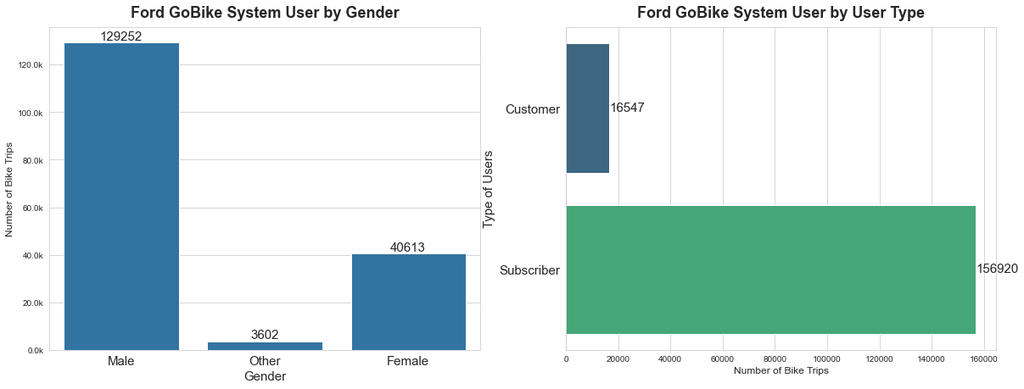

## Age of Users for every bike trip

> From this image, The data is skewed to the right and it also stops at age 67 due to the outliers after such age. Majority of the users are mainly between 25 to 40 years of age and this is the average age of people in the workforce. This further confirms the assumption of the Usage of these bikes in the workforce of San Francisco. We can then further ask questions like Are they used for exercise in the morning or evening?

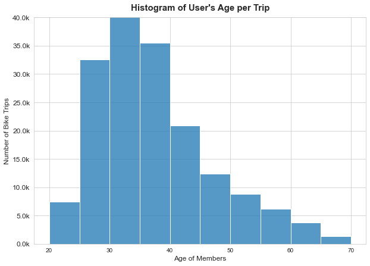

## Start Time and Distance Covered During Bike Trips

> From the figures , The times when the trips start are concentrated mainly in between 8-9am and 4-6pm. Most people in the workforce work from 9-5pm. This shows that majority of the subscribers or Users use this bike to get to work or leave their workplace. The second figure shows the distance covered by the users. The histogram is unimodal and skewed to the right. Most users do not use more than 2km on the bike before ending the trip.

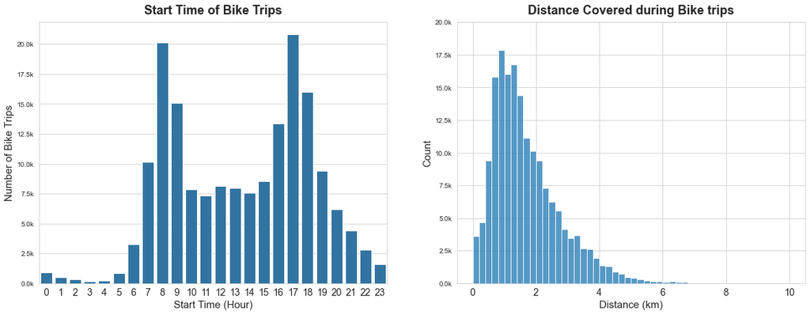

## Distance Covered and Bike Trips of every day of week for User Types

> Both the Customer's and the Subscriber's distance covered are skewed to the right and majority of them take the bikes on 2km trip at most. This figures also shows the low usage of customers compared to th high usage of the subscribers. From the countplot, There is a large decrease from the weekdays to the weekends for the subscribers while there is an increase from Thursday for the customers. This figure shows that the customers might not be from the area. They might be tourist or students looking throught the city of San Francisco.

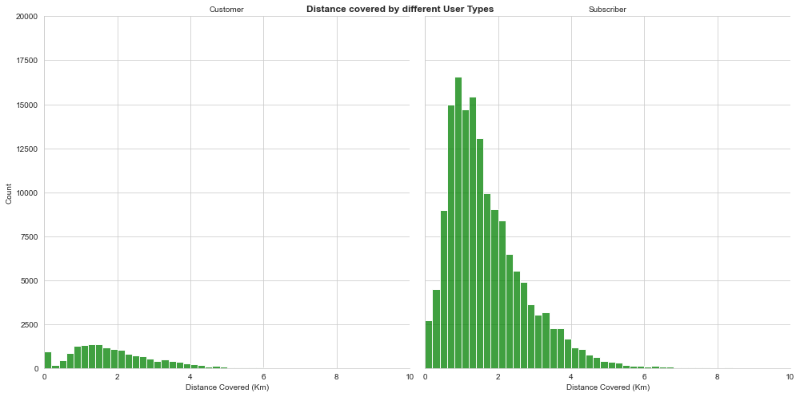

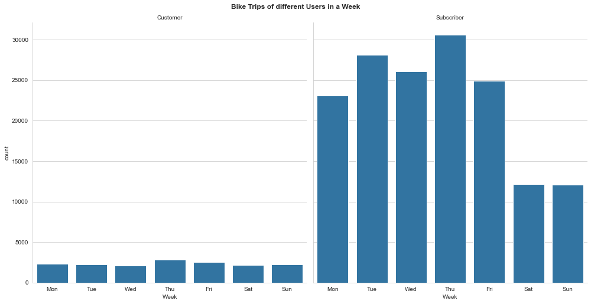

## Distance Covered by Subscribers and Customers during each day of the week

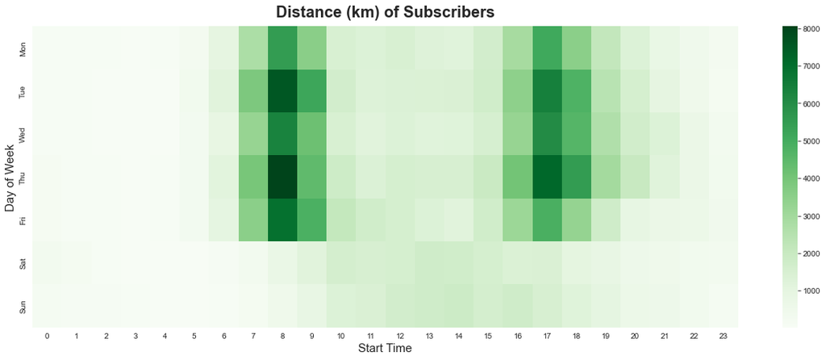

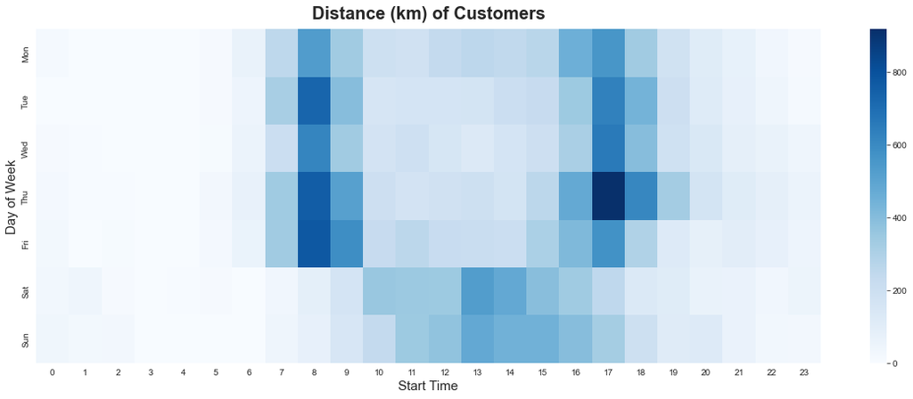

## Conclusions

> In the race between vehicles and trains, this project is a wise choice. Here are some of its advantages:
> - Environmentally sustainable, cost-effective, and lifestyle-friendly.
> - Subscribers, or daily commuters, gain from a healthy transportation option.
> - Customers (such as visitors, students, etc.) have a flexible yet environmentally friendly alternative for exploring the city.
> - Accessible and affordable transit for all socioeconomic groups

[output not shown]